# Bayesian GLMM example 7

Murray Logan

28 May, 2022

# Preparations

Load the necessary libraries

```r
library(car)       #for regression diagnostics
library(broom)     #for tidy output
library(ggfortify) #for model diagnostics
library(sjPlot)    #for outputs
library(knitr)     #for kable
library(effects)   #for partial effects plots
library(emmeans)   #for estimating marginal means
library(MASS)      #for glm.nb
library(MuMIn)     #for AICc
library(tidyverse) #for data wrangling
library(brms)
library(tidybayes)
library(broom.mixed)
library(rstan)
library(patchwork)
library(DHARMa)
```

# Scenario

In an honours thesis from (1992), Mullens was investigating the ways that cane toads ( Bufo marinus ) respond to conditions of hypoxia. Toads show two different kinds of breathing patterns, lung or buccal, requiring them to be treated separately in the experiment. Her aim was to expose toads to a range of O<sub>2</sub> concentrations, and record their breathing patterns, including parameters such as the expired volume for individual breaths. It was desirable to have around 8 replicates to compare the responses of the two breathing types, and the complication is that animals are expensive, and different individuals are likely to have different O<sub>2</sub> profiles (leading to possibly reduced power). There are two main design options for this experiment;

- One animal per O<sub>2</sub> treatment, 8 concentrations, 2 breathing types. With 8 replicates the experiment would require 128 animals, but that this could be analysed as a completely randomized design
- One O<sub>2</sub> profile per animal, so that each animal would be used 8 times and only 16 animals are required (8 lung and 8 buccal breathers)

Mullens decided to use the second option so as to reduce the number of animals required (on financial and ethical grounds). By selecting this option, she did not have a set of independent measurements for each oxygen concentration, by repeated measurements on each animal across the 8 oxygen concentrations.

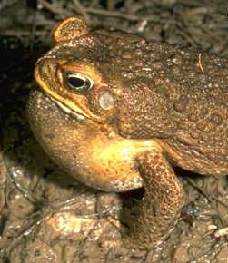

Toad

Format of mullens.csv data file

| BREATH | TOAD | O2LEVEL | FREQBUC | SFREQBUC |
| --- | --- | --- | --- | --- |
| lung | a | 0 | 10.6 | 3.256 |
| lung | a | 5 | 18.8 | 4.336 |
| lung | a | 10 | 17.4 | 4.171 |
| lung | a | 15 | 16.6 | 4.074 |
| ... | ... | ... | ... | ... |

[output not shown]

# Read in the data

```r
mullens = read_csv('../public/data/mullens.csv', trim_ws=TRUE)
glimpse(mullens)
```

```
## Rows: 168
## Columns: 5
## $ BREATH   <chr> "lung", "lung", "lung", "lung", "lung", "lung", "lung", "lung…
## $ TOAD     <chr> "a", "a", "a", "a", "a", "a", "a", "a", "b", "b", "b", "b", "…
## $ O2LEVEL  <dbl> 0, 5, 10, 15, 20, 30, 40, 50, 0, 5, 10, 15, 20, 30, 40, 50, 0…
## $ FREQBUC  <dbl> 10.6, 18.8, 17.4, 16.6, 9.4, 11.4, 2.8, 4.4, 21.6, 17.4, 22.4…
## $ SFREQBUC <dbl> 3.255764, 4.335897, 4.171331, 4.074310, 3.065942, 3.376389, 1…
```

# Exploratory data analysis

Model formula:
$$y_i \sim{} \mathcal{Pois}(\lambda_i)\\
ln(\lambda_i) =\boldsymbol{\beta} \bf{X_i} + \boldsymbol{\gamma} \bf{Z_i}$$

In this example, the individual `TOAD`s are the random blocks. Each toad can only be of one `BREATH` type (they are either predominantly buccal breathers or predominantly lung breathers). Hence, `BREATH` is a between `TOAD` (block) effect. The frequency of buccal breathing of ach `TOAD` was measured under eight different oxygen levels and thus, these represent the within block effect, as will the interaction between breathing type and oxygen level.

The response in this case is a little tricky since it is a proportion, but without the full original measurements. For example a frequency of 50% would indicate that half of the breaths taken by the toad during the monitoring phase were buccal breaths. Ideally, it would be good to have the actual counts (both the number of buccal breaths and the total number of breaths). That way, we could model the data against a binomial distribution.

As it is, we only have the proportion (as a percentage). Although we could model this against a beta distribution, this could be complicated if there are proportions of either 0 or 1 (100).

To help guide us through this and the other typical model assumptions, lets start by graphing the frequency of buccal breathing against breathing type and oxygen level. However, before we do, we need to make sure that all categorical variables are declared as factors (including the random effect). If we intend to model against a beta distribution, we will need a version of the response that is represented on a scale between 0 and 1 (but not include 0 or 1).

```r
mullens = mullens %>%
  mutate(BREATH=factor(BREATH),
         TOAD=factor(TOAD),
         pBUC=FREQBUC/100,
         pzBUC=ifelse(pBUC==0,0.01,pBUC))
```

So starting with the raw response.

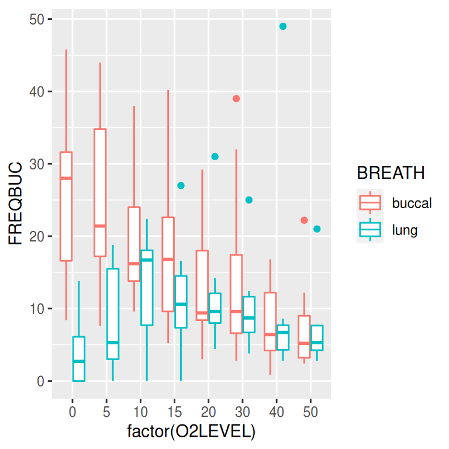

```r
ggplot(mullens,aes(y=FREQBUC, x=factor(O2LEVEL), color=BREATH)) +
    geom_boxplot()
```

**Conclusions:**

- there is a very clear relationship between mean and variance (boxplots that are higher up the y-axis are taller).
- it might be possible to address this via a logarithmic or root transformation, however this is the least favourable option (particularly root transformations due to issues with back-transformations).

If we intend to use a beta distribution, we could repeat the above with the scaled response. Since the rescaling maintains the same ranking and relative spacing, the plot will look the same as above, just with a different y-axis. However, our interpretation will change. Under a beta distribution (with logit link), we expect that the variance and mean will be related. We expect that the distributions will become more varied and more symmetrical as the expected mean shifts towards 0.5. Distributions approaching 0 and 1 will be more asymmetrical and smaller. This indeed does seem to be the case here.

Now lets explore the oxygen trends (separately for each breathing type).

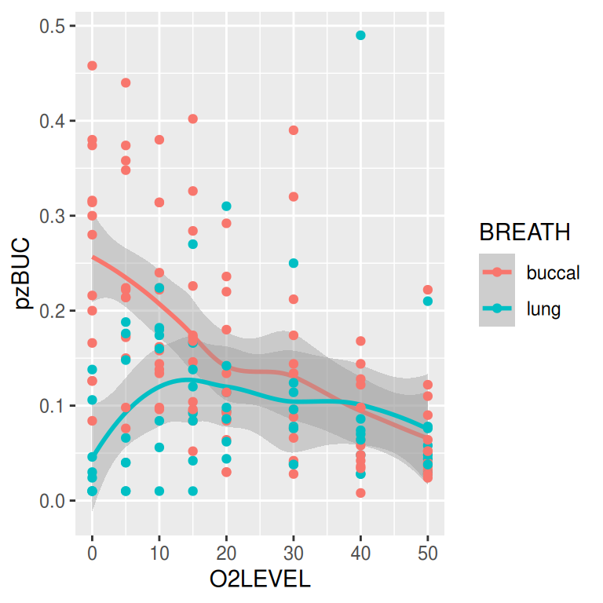

```r
ggplot(mullens,aes(y=pzBUC, x=O2LEVEL, color=BREATH)) +
    geom_smooth() + geom_point()
```

**Conclusions:**

- although linearity seems reasonable for the buccal breathers, there is definitely evidence of non linearity in the lung breathers.
- it might be interesting to fit polynomial trends for oxygen concentration.

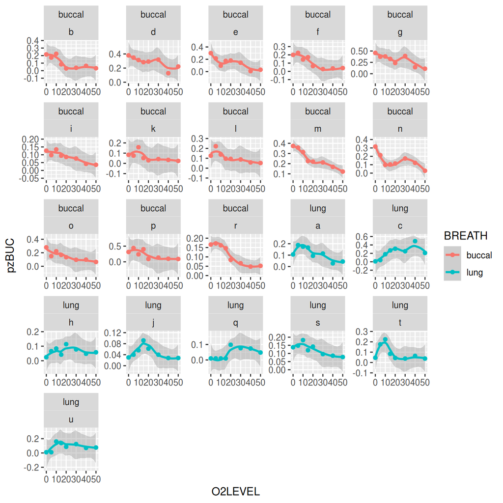

```r
ggplot(mullens,aes(y=pzBUC, x=O2LEVEL, color=BREATH)) +
  geom_smooth() + geom_point() +
  facet_wrap(~BREATH+TOAD, scales='free')
```

```r
  #facet_grid(TOAD~BREATH)
```

**Conclusions:**

- it does appear that different toads (within the same breathing type) have very different levels of buccal breathing
- the individual toads also have varying responses to changes in oxygen concentration
- it might be useful to explore random intercept/slope models.

# Fit the model

## beta

### brms

```r
mullens %>% group_by(BREATH) %>%
    summarise(logit(median(pBUC)),
              logit(mad(pBUC)))

standist::visualize('gamma(0.01, 0.01)', xlim=c(0,1))
standist::visualize('beta(1,1)', xlim=c(0,1))
priors <- prior(normal(0, 5), class='Intercept') +
    prior(normal(0,5), class='b') +
    prior(gamma(2,1), class='sd') +
    prior(gamma(0.01, 0.01), class='phi') +
    prior(beta(1,1), class='zoi')

mullens.form <- bf(pBUC ~ BREATH*poly(O2LEVEL,3) + (1|TOAD),
                   family=zero_one_inflated_beta())

mullens.brm <- brm(mullens.form,
                   data=mullens,
                   prior = priors,
                   sample_prior = 'yes',
                   iter=5000, warmup=2500,
                   thin=5, chains=3, cores=3)
##prior_summary(mullens.brm)


pars <- mullens.brm %>% get_variables()
wch <- grepl('^b_.*|^sd_.*|phi', pars, perl=TRUE)

g <- vector('list', length=sum(wch)-1)
names(g) <- pars[wch][-1]
for (i in pars[wch]) {
    print(i)
    if (i == 'b_Intercept') next
    p <- mullens.brm %>% hypothesis(paste0(i,'=0'), class='') %>% plot()
    g[[i]] <- p[[1]]
}
patchwork::wrap_plots(g)

stan_trace(mullens.brm$fit, pars = pars[wch])
stan_ac(mullens.brm$fit, pars = pars[wch])
stan_rhat(mullens.brm$fit, pars = pars[wch])
stan_rhat(mullens.brm$fit)
stan_ess(mullens.brm$fit)


preds <- posterior_predict(mullens.brm,  nsamples=250,  summary=FALSE)
mullens.resids <- createDHARMa(simulatedResponse = t(preds),
                            observedResponse = mullens$pBUC,
                            fittedPredictedResponse = apply(preds, 2, median),
                            integerResponse = FALSE)
plot(mullens.resids)
testDispersion(mullens.resids)


priors <- prior(normal(-1.9, 2), class='Intercept') +
    prior(normal(0,2), class='b') +
    prior(cauchy(0,5), class='sd') +
    prior(normal(0, 5), class='Intercept', dpar='phi') +
    prior(logistic(0,1), class='Intercept', dpar='coi') +
    prior(logistic(0,1), class='Intercept', dpar='zoi') +
    prior(cauchy(0,5), class='sd', dpar='coi') +
    prior(cauchy(0,5), class='sd', dpar='phi') +
    prior(cauchy(0,5), class='sd', dpar='zoi')

prior(gamma(2,1), class='sd', dpar='coi') +
    prior(gamma(2,1), class='sd', dpar='phi') +
    prior(gamma(2,1), class='sd', dpar='zoi')


mullens.form <- bf(pBUC ~ BREATH*poly(O2LEVEL,3) + (poly(O2LEVEL,3)|TOAD),
                   phi ~ (1|TOAD),
                   coi ~ (1|TOAD),
                   zoi ~ (1|TOAD),#BREATH*poly(O2LEVEL,3),
                   family=zero_one_inflated_beta())

mullens.brm <- brm(mullens.form,
                   data=mullens,
                   prior = priors,
                   sample_prior = 'yes',
                   iter=5000, warmup=2500,
                   thin=5, chains=3, cores=3,
                   control=list(adapt_delta=0.99))

prior_summary(mullens.brm)
mullens.brm %>% conditional_effects() %>% plot(points=TRUE)

g <- mullens.brm %>%
    conditional_effects() %>%
    plot(points=TRUE, ask=FALSE, plot=FALSE)
patchwork::wrap_plots(g)

pars <- mullens.brm %>% get_variables()
pars
wch <- grepl('^b_.*|^sd_.*', pars, perl=TRUE)

g <- vector('list', length=sum(wch))
names(g) <- pars[wch]
for (i in pars[wch]) {
    print(i)
    p <- mullens.brm %>% hypothesis(paste0(i,'=0'), class='') %>% plot()
    g[[i]] <- p[[1]]
}
patchwork::wrap_plots(g)

stan_trace(mullens.brm$fit, pars = pars[wch])
stan_ac(mullens.brm$fit, pars = pars[wch])
stan_rhat(mullens.brm$fit, pars = pars[wch])
stan_rhat(mullens.brm$fit)
stan_ess(mullens.brm$fit)


summary(mullens.brm)


mullens.brm %>% emtrends(specs='BREATH', var='O2LEVEL', max.degree=3) %>%
    gather_emmeans_draws() %>%
    median_hdci()

mullens.grid <- with(mullens, list(O2LEVEL = modelr::seq_range(O2LEVEL, n=10000)))
mullens.em <- mullens.brm %>%
    emmeans(~O2LEVEL|BREATH, at=mullens.grid, type='response') %>%
    gather_emmeans_draws() %>%
    mutate(Fit=exp(.value))

mullens.em %>%
    median_hdci(Fit) %>%
    ggplot(aes(y=Fit, x=O2LEVEL, color=BREATH)) +
    geom_line() +
    geom_ribbon(aes(ymin=.lower, ymax=.upper, fill=BREATH), color=NA, alpha=0.3)


mullens.em %>%
    ungroup() %>%
    group_by(BREATH, .draw) %>%
    summarise(Max=O2LEVEL[which.max(.value)]) %>%
    ungroup() %>%
    group_by(BREATH) %>%
    median_hdci(Max)
```

### fixed structure

```r
mullens.glmmTMB2a = glmmTMB(pzBUC ~ BREATH*poly(O2LEVEL, 3) + (1|TOAD), data=mullens,
                            family=beta_family(link = "logit"),  REML=FALSE)
mullens.glmmTMB2b = update(mullens.glmmTMB2a,  .~.-BREATH:poly(O2LEVEL,  3))
AICc(mullens.glmmTMB2a,  mullens.glmmTMB2b)
```

**Conclusions:**

### random structure

```r
mullens.glmmTMB2a = update(mullens.glmmTMB2a,  REML=TRUE)
mullens.glmmTMB2b = update(mullens.glmmTMB2a,  ~ . - (1|TOAD) + (poly(O2LEVEL, 3)|TOAD))
AICc(mullens.glmmTMB2a,  mullens.glmmTMB2b)
```

**Conclusions:**

# Model validation

## sqrt (gaussian) with lmer

### plot_model

```r
plot_model(mullens.lmer1a, type='diag')[-2] %>% plot_grid
```

### Performance model checking

```r
performance::check_model(mullens.lmer1a)
```

### DHARMa residuals

```r
mullens.resid <- simulateResiduals(mullens.lmer1a,  plot=TRUE)
```

## sqrt (gaussian)

### plot_model

```r
plot_model(mullens.glmmTMB1a, type='diag')[-2] %>% plot_grid
```

### Performance model checking

```r
performance::check_model(mullens.glmmTMB1a)
```

### DHARMa residuals

```r
mullens.resid <- simulateResiduals(mullens.glmmTMB1a,  plot=TRUE)
```

## beta

### plot_model

```r
plot_model(mullens.glmmTMB2b, type='diag')[-2] %>% plot_grid
```

### Performance model checking

```r
performance::check_model(mullens.glmmTMB2b)
```

### DHARMa residuals

```r
mullens.resid <- simulateResiduals(mullens.glmmTMB2a,  plot=TRUE)
mullens.resid <- simulateResiduals(mullens.glmmTMB2b,  plot=TRUE)
```

```r
ggemmeans(mullens.glmmTMB2b, ~O2LEVEL|BREATH) %>% plot(add.data=TRUE)
```

# Model investigation / hypothesis testing

## sqrt (gaussian) with lmer

### summary

```r
summary(mullens.lmer1a)
```

- The parameters are presented on a root scale from which it can be dangerous to back-transform. Hence the parameters themselves have little value (other which were not found to be significant).
- this might imply that the lung breathing toads have a quadratic trend, but this is not formally tested here.
- there is approximately the same amount of variation between toads (within breathing types) as there is within toads (for a given oxygen concentration).

### tidy

```r
tidy(mullens.lmer1a,  conf.int=TRUE)
tidy(mullens.lmer1a,  conf.int=TRUE) %>% kable
```

**Conclusions:**

- The parameters are presented on a root scale from which it can be dangerous to back-transform. Hence the parameters themselves have little value (other which were not found to be significant).
- this might imply that the lung breathing toads have a quadratic trend, but this is not formally tested here.
- there is approximately the same amount of variation between toads (within breathing types) as there is within toads (for a given oxygen concentration).

### tab_model

```r
# warning this is only appropriate for html output
sjPlot::tab_model(mullens.lmer1a, show.se=TRUE, show.aic=TRUE)
```

### anova

```r
# with Satterthwaite degrees of freedom calculations
anova(mullens.lmer1a)
#OR with Keyward-Roger degrees of freedom calculations
anova(mullens.lmer1a,  ddf='Kenward-Roger')
```

## sqrt (gaussian)

### summary

```r
summary(mullens.glmmTMB1a)
```

- The parameters are presented on a root scale from which it can be dangerous to back-transform. Hence the parameters themselves have little value (other which were not found to be significant).
- this might imply that the lung breathing toads have a quadratic trend, but this is not formally tested here.
- there is approximately the same amount of variation between toads (within breathing types) as there is within toads (for a given oxygen concentration).

### tidy

```r
tidy(mullens.glmmTMB1a,  conf.int=TRUE)
tidy(mullens.glmmTMB1a,  conf.int=TRUE) %>% kable
```

**Conclusions:**

- The parameters are presented on a root scale from which it can be dangerous to back-transform. Hence the parameters themselves have little value (other which were not found to be significant).
- this might imply that the lung breathing toads have a quadratic trend, but this is not formally tested here.
- there is approximately the same amount of variation between toads (within breathing types) as there is within toads (for a given oxygen concentration).

### tab_model

```r
# warning this is only appropriate for html output
sjPlot::tab_model(mullens.glmmTMB1a, show.se=TRUE, show.aic=TRUE)
```

## beta

### summary

```r
summary(mullens.glmmTMB2b)
```

**Conclusions:**

### tidy

```r
tidy(mullens.glmmTMB2b,  conf.int=TRUE)
tidy(mullens.glmmTMB2b,  conf.int=TRUE, exponentiate=TRUE)
tidy(mullens.glmmTMB2b,  conf.int=TRUE, exponentiate=TRUE) %>% kable
```

### tab_model

```r
# warning this is only appropriate for html output
sjPlot::tab_model(mullens.glmmTMB2b, show.se=TRUE, show.aic=TRUE)
```

# Further analyses

## sqrt (gaussian) with lmer

```r
emtrends(mullens.lmer1a,  specs='BREATH',  var='O2LEVEL',  max.degree=3,  infer=c(TRUE, TRUE))

newdata <- with(mullens,  list(O2LEVEL=seq(min(O2LEVEL),  max(O2LEVEL),  len=100),
                               BREATH=levels(BREATH)))
mullens.grid <- emmeans(mullens.lmer1a,  ~O2LEVEL|BREATH,  at=newdata) %>% as.data.frame
mullens.grid %>% group_by(BREATH) %>%
  summarise(value = O2LEVEL[which.max(emmean)])
emtrends(mullens.glmmTMB2b,  specs='BREATH',  var='O2LEVEL',
         max.degree=3,  infer=c(TRUE, TRUE))

newdata <- with(mullens,  list(O2LEVEL=seq(min(O2LEVEL),  max(O2LEVEL),  len=100),
                               BREATH=levels(BREATH)))
mullens.grid <- emmeans(mullens.lmer1a,  ~O2LEVEL|BREATH,  at=newdata) %>% as.data.frame
mullens.grid %>% group_by(BREATH) %>%
  summarise(value = O2LEVEL[which.max(emmean)])
```

**Conclusions:**

- the rate of buccal breathing by buccal breathing toads declines linearly with increasing oxygen concentration
- the rate of buccal breathing by lung breathing toads as oxygen concentration increases follows a quadratic trend. Initially, as oxygen concentrations increases, the rate of buccal breathing increases up to an oxygen concentration of approximately 20 percent, after which it declines.

## sqrt (gaussian)

```r
emtrends(mullens.glmmTMB1a,  specs='BREATH',  var='O2LEVEL',  max.degree=3,  infer=c(TRUE, TRUE))

newdata <- with(mullens,  list(O2LEVEL=modelr::seq_range(O2LEVEL, n=1000),
                               BREATH=levels(BREATH)))
mullens.grid <- emmeans(mullens.glmmTMB1a,  ~O2LEVEL|BREATH,  at=newdata) %>% as.data.frame
mullens.grid %>% group_by(BREATH) %>%
  summarise(value = O2LEVEL[which.max(emmean)])
```

**Conclusions:**

- the rate of buccal breathing by buccal breathing toads declines linearly with increasing oxygen concentration
- the rate of buccal breathing by lung breathing toads as oxygen concentration increases follows a quadratic trend. Initially, as oxygen concentrations increases, the rate of buccal breathing increases up to an oxygen concentration of approximately 20 percent, after which it declines.

## beta

```r
emtrends(mullens.glmmTMB2b,  specs='BREATH',  var='O2LEVEL',  max.degree=3,  infer=c(TRUE, TRUE))

## newdata <- with(mullens,  list(O2LEVEL=seq(min(O2LEVEL),  max(O2LEVEL),  len=100),
##                                BREATH=levels(BREATH)))
mullens.grid <- with(mullens,  list(O2LEVEL=modelr::seq_range(O2LEVEL, n=1000),
                               BREATH=levels(BREATH)))
newdata <- emmeans(mullens.glmmTMB2b,  ~O2LEVEL|BREATH,  at=mullens.grid) %>% as.data.frame
newdata %>% group_by(BREATH) %>%
  summarise(value = O2LEVEL[which.max(emmean)])
## r.squaredGLMM(mullens.glmmTMB2a)
performance::r2_nakagawa(mullens.glmmTMB2a)
```

**Conclusions:**

- the rate of buccal breathing by buccal breathing toads declines linearly with increasing oxygen concentration
- the rate of buccal breathing by lung breathing toads as oxygen concentration increases follows a quadratic trend. Initially, as oxygen concentrations increases, the rate of buccal breathing increases up to an oxygen concentration of approximately 20 percent, after which it declines.

# Summary figures

## sqrt (gaussian) with lmer

```r
mullens.grid = with(mullens,
   list(BREATH=levels(BREATH),
     O2LEVEL=seq(min(O2LEVEL), max(O2LEVEL), len=100)
   )
)
newdata = emmeans(mullens.lmer1a, ~O2LEVEL|BREATH,
                  at=mullens.grid, type='response') %>% as.data.frame %>%
          mutate(emmean = emmean^2,
                 lower.CL=lower.CL^2,
                 upper.CL=upper.CL^2)
head(newdata)

ggplot() +
    geom_ribbon(data=newdata,
                aes(ymin=lower.CL,ymax=upper.CL,
                    x=O2LEVEL, fill=BREATH), alpha=0.3)+
    geom_line(data=newdata,
              aes(y=emmean, x=O2LEVEL, color=BREATH)) +
    theme_classic()
```

## sqrt (gaussian)

```r
mullens.grid = with(mullens,
   list(BREATH=levels(BREATH),
     O2LEVEL=seq(min(O2LEVEL), max(O2LEVEL), len=100)
   )
)
newdata = emmeans(mullens.glmmTMB1a, ~O2LEVEL|BREATH,
                  at=mullens.grid, type='response') %>% as.data.frame %>%
          mutate(emmean = emmean^2,
                 lower.CL=lower.CL^2,
                 upper.CL=upper.CL^2)
head(newdata)

ggplot() +
    geom_ribbon(data=newdata,
                aes(ymin=lower.CL,ymax=upper.CL,
                    x=O2LEVEL, fill=BREATH), alpha=0.3)+
    geom_line(data=newdata,
              aes(y=emmean, x=O2LEVEL, color=BREATH)) +
    theme_classic()
```

## beta

```r
mullens.grid = with(mullens,
   list(BREATH=levels(BREATH),
     O2LEVEL=modelr::seq_range(O2LEVEL, n=1000)
   )
)
newdata = emmeans(mullens.glmmTMB2b, ~O2LEVEL|BREATH,
                  at=mullens.grid, type='response') %>% as.data.frame
head(newdata)

ggplot() +
    geom_ribbon(data=newdata,
                aes(ymin=lower.CL,ymax=upper.CL,
                    x=O2LEVEL, fill=BREATH), alpha=0.3)+
    geom_line(data=newdata,
              aes(y=response, x=O2LEVEL, color=BREATH)) +
    theme_classic()

mullens <- mullens %>%
    mutate(resid=resid(mullens.glmmTMB2b),
           fitted=fitted(mullens.glmmTMB2b),
           obs=fitted+resid
           )

ggplot() +
    geom_point(data=mullens, aes(y=obs, x=O2LEVEL, color=BREATH)) +
    geom_ribbon(data=newdata,
                aes(ymin=lower.CL,ymax=upper.CL,
                    x=O2LEVEL, fill=BREATH), alpha=0.3)+
    geom_line(data=newdata,
              aes(y=response, x=O2LEVEL, color=BREATH)) +
    theme_classic()
```

```r
mullens.glmmTMB = glmmTMB(pzBUC ~ BREATH*poly(O2LEVEL, 3) + (1|TOAD), data=mullens,
                          family=beta_family(link = "logit"))

#mullens.glmmTMB1 = glmmTMB(pzBUC ~ BREATH*poly(scale(O2LEVEL), 3) +
#                               (poly(scale(O2LEVEL), 3)|TOAD), data=mullens,
#                          family=beta_family(link = "logit"))

mullens.glmmTMB1 = glmmTMB(pzBUC ~ BREATH*poly(O2LEVEL, 3) + (O2LEVEL|TOAD), data=mullens,
                           family=beta_family(link = "logit"))
AIC(mullens.glmmTMB, mullens.glmmTMB1)


## library(lme4)
## mullens.glmer = glmer(pBUC ~ BREATH*poly(O2LEVEL, 3) + (1|TOAD),
##                       data=mullens, family=Beta(link='logit'))
## mullens.glmer1 = glmer(pBUC ~ BREATH*poly(O2LEVEL, 3) + (BREATH|TOAD),
##                       data=mullens, family=binomial(link='logit'))
## AIC(mullens.glmer,mullens.glmer1)
##                                         # Try this trick instead
## mullens.glmer = glmer(cbind(FREQBUC,100-FREQBUC) ~ BREATH*poly(O2LEVEL, 3) + (1|TOAD),
##                       data=mullens, family=binomial(link='logit'))

## mullens.glmer1 = glmer(cbind(FREQBUC,100-FREQBUC) ~ BREATH+poly(O2LEVEL, 3) + (1|TOAD),
##                       data=mullens, family=binomial(link='logit'))
## AICc(mullens.glmer, mullens.glmer1)

#ggplot() +
#    geom_point(data=NULL, aes(y=resid(mullens.glmmTMB), x=fitted(mullens.glmmTMB)))


#plot(mullens.glmmTMB)


plot_model(mullens.glmmTMB1, type='diag')
performance::check_model(mullens.glmmTMB1)
mullens.resid = simulateResiduals(mullens.glmmTMB1,  plot=TRUE)

plot(allEffects(mullens.glmmTMB1))
plot(allEffects(mullens.glmmTMB1),  multiline=TRUE,  ci.style='bands')
plot_model(mullens.glmmTMB1, type='eff', terms=c('O2LEVEL', 'BREATH'))


summary(mullens.glmmTMB1)
tidy(mullens.glmmTMB1, conf.int=TRUE,  exponentiate=TRUE)

#model.matrix(~BREATH*poly(O2LEVEL,3), mullens)
emtrends(mullens.glmmTMB1,  ~BREATH,  var='O2LEVEL',  max.degree=3)

emmeans(mullens.glmmTMB1, ~O2LEVEL|BREATH) #%>% as.data.frame

emmeans(mullens.glmmTMB1, ~O2LEVEL|BREATH,type='response')
#contrast(emmeans(mullens.glmmTMB, ~O2LEVEL|BREATH,type='response'),interaction='poly')

mullens.grid = with(mullens,
   list(BREATH=levels(BREATH),
     O2LEVEL=seq(min(O2LEVEL), max(O2LEVEL), len=100)
   )
)
newdata = emmeans(mullens.glmmTMB1, ~O2LEVEL|BREATH,
        at=mullens.grid, type='response') %>% as.data.frame
head(newdata)

ggplot() +
    geom_ribbon(data=newdata,
                aes(ymin=lower.CL,ymax=upper.CL,
                    x=O2LEVEL, fill=BREATH), alpha=0.3)+
    geom_line(data=newdata,
              aes(y=response, x=O2LEVEL, color=BREATH)) +
    theme_classic()

r.squaredGLMM(mullens.glmmTMB1)
performance::r2_nakagawa(mullens.glmmTMB1)
```